```python
from matplotlib import pyplot as plt
import pandas as pd
import numpy as np
import statsmodels.api as sm
import statsmodels.formula.api as smf

%matplotlib inline
```

# Electricity Demand Model

A demand model for the electricity consumption of individuel households is beeing estimated. The data consists of time series for electricity consumption (as the endogen variable) and electricity prices and the individual GDP (as the exogen variables). The observed time frame starts in 1978 and ends in 2008. The data is prepared and adjusted for comparability by the correspondent index.

```python
consumption = pd.read_csv('~/energy/demand.csv', sep=';', index_col=0).T
price = pd.read_csv('~/energy/price.csv', sep=';', index_col=0).T
price.columns = ['price_finland', 'price_norway']
gdp = pd.read_csv('~/energy/gdp.csv', sep=';', index_col=0).T
gdp.columns = ['GDP_finland', 'GDP_norway']
index = pd.read_csv('~/energy/index.csv', sep=';', index_col=0).T
index.columns = ['index_finland', 'index_norway']

gdp_price = price.join(gdp) #gdp 1970, price 1978
gdp_price = gdp_price.join(index)

consumption = consumption*11.63/1000 #ktoe -> TWh
gdp_price['GDP_real_Finland'] = (gdp_price['GDP_finland']/gdp_price['index_finland'])*100
gdp_price['GDP_real_Norway'] = (gdp_price['GDP_norway']/gdp_price['index_norway'])*100

gdp_price['price_real_Finland'] = gdp_price['price_finland']/gdp_price['index_finland']*100
gdp_price['price_real_Norway'] = gdp_price['price_norway']/gdp_price['index_norway']*100

energy_consumption = gdp_price.join(consumption)
```

```python
consumption.head()
```

|  | Finland | Norway |
| --- | --- | --- |
| 1960 | 0.713128 | 8.134464 |
| 1961 | 0.732132 | 8.453521 |
| 1962 | 0.870157 | 9.529715 |
| 1963 | 0.989178 | 10.343862 |
| 1964 | 1.083195 | 10.962973 |

```python
energy_consumption.head()
```

|  | price_finland | price_norway | GDP_finland | GDP_norway | index_finland | index_norway | GDP_real_Finland | GDP_real_Norway | price_real_Finland | price_real_Norway | Finland | Norway |
| --- | --- | --- | --- | --- | --- | --- | --- | --- | --- | --- | --- | --- |
| 1978 | 0.05 | 0.02 | 24.9 | 26.5 | 34.23 | 32.22 | 72.743208 | 82.247052 | 0.146071 | 0.062073 | 7.383329 | 20.944769 |
| 1979 | 0.05 | 0.02 | 29.0 | 29.6 | 37.23 | 34.37 | 77.894171 | 86.121618 | 0.134300 | 0.058190 | 7.754396 | 22.349022 |
| 1980 | 0.06 | 0.02 | 33.5 | 35.4 | 40.87 | 39.39 | 81.967213 | 89.870526 | 0.146807 | 0.050774 | 8.057450 | 22.527054 |
| 1981 | 0.06 | 0.02 | 38.0 | 40.7 | 45.40 | 44.90 | 83.700441 | 90.645880 | 0.132159 | 0.044543 | 8.430517 | 23.877297 |
| 1982 | 0.07 | 0.03 | 42.6 | 45.0 | 49.40 | 49.40 | 86.234818 | 91.093117 | 0.141700 | 0.060729 | 8.985617 | 25.084514 |

The relationship between electricity consumption (demand) vs price and GDP can be analyzed graphically before any model is fitted.

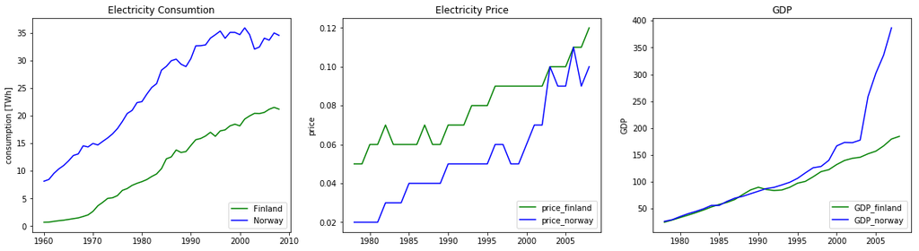

```python
fig = plt.figure(figsize=(20,5))
plt.subplot(131)
plt.plot(consumption['Finland'], 'g-')
plt.plot(consumption['Norway'], 'b-')
plt.ylabel('consumption [TWh]')
plt.legend(loc='lower right')
plt.title('Electricity Consumtion')

plt.subplot(132)
plt.plot(gdp_price['price_finland'], 'g-')
plt.plot(gdp_price['price_norway'], 'b-')
plt.ylabel('price')
plt.legend(loc='lower right')
plt.title('Electricity Price')

plt.subplot(133)
plt.plot(gdp_price['GDP_finland'], 'g-')
plt.plot(gdp_price['GDP_norway'], 'b-')
plt.ylabel('GDP')
plt.legend(loc='lower right')
plt.title('GDP')
```

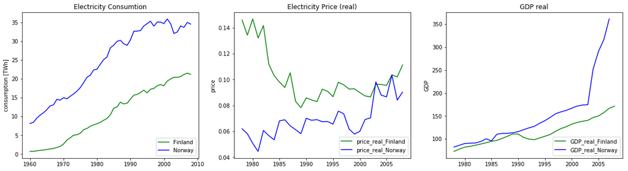

```python
fig = plt.figure(figsize=(20,5))
plt.subplot(131)
plt.plot(consumption['Finland'], 'g-')
plt.plot(consumption['Norway'], 'b-')
plt.ylabel('consumption [TWh]')
plt.legend(loc='lower right')
plt.title('Electricity Consumtion')

plt.subplot(132)
plt.plot(gdp_price['price_real_Finland'], 'g-')
plt.plot(gdp_price['price_real_Norway'], 'b-')
plt.ylabel('price')
plt.legend(loc='lower right')
plt.title('Electricity Price (real)')

plt.subplot(133)
plt.plot(gdp_price['GDP_real_Finland'], 'g-')
plt.plot(gdp_price['GDP_real_Norway'], 'b-')
plt.ylabel('GDP')
plt.legend(loc='lower right')
plt.title('GDP real')
```

## Model Selection

A linear model is now fitted to the data. Four different models are beeing compared. They differ in the amount of variables used.

### Model 1

$$E_t = K p_t^\alpha Y_t^\beta,$$

where $E_t$ is the demanded electricity at time $t$, $p_t$ is the price at time $t$, and $Y_t$ is the GDP. $\alpha$ is the price elasticity and $\beta$ is the income elasticity.

Transformed into a linear model results in: $$log(E_t) = log(K) + \alpha*log(p_t) + \beta*log(Y_t)$$

```python
mod1f = smf.ols(formula='np.log(Finland) ~ np.log(GDP_real_Finland) + np.log(price_real_Finland)', data=energy_consumption).fit()
mod1f.summary()
```

OLS Regression Results

| Dep. Variable: | np.log(Finland) | R-squared: | 0.921 |
| --- | --- | --- | --- |
| Model: | OLS | Adj. R-squared: | 0.915 |
| Method: | Least Squares | F-statistic: | 162.6 |
| Date: | Thu, 16 Nov 2017 | Prob (F-statistic): | 3.87e-16 |
| Time: | 15:41:47 | Log-Likelihood: | 29.819 |
| No. Observations: | 31 | AIC: | -53.64 |
| Df Residuals: | 28 | BIC: | -49.34 |
| Df Model: | 2 |  |  |
| Covariance Type: | nonrobust |  |  |

|  | coef | std err | t | P>\|t\| | [0.025 | 0.975] |
| --- | --- | --- | --- | --- | --- | --- |
| Intercept | -3.9819 | 0.373 | -10.685 | 0.000 | -4.745 | -3.219 |
| np.log(GDP_real_Finland) | 1.0970 | 0.088 | 12.406 | 0.000 | 0.916 | 1.278 |
| np.log(price_real_Finland) | -0.6502 | 0.117 | -5.550 | 0.000 | -0.890 | -0.410 |

| Omnibus: | 0.988 | Durbin-Watson: | 0.833 |
| --- | --- | --- | --- |
| Prob(Omnibus): | 0.610 | Jarque-Bera (JB): | 0.215 |
| Skew: | -0.074 | Prob(JB): | 0.898 |
| Kurtosis: | 3.379 | Cond. No. | 116. |

### Model 2

The second model contains an additional exponential trend.

$$E_t = K p_t^\alpha Y_t^\beta e^{\theta t},$$

$$log(E_t) = log(K) + \alpha*log(p_t) + \beta*log(Y_t) + \theta*t$$

```python
#energy_consumption.reset_index(level=0, inplace=True)
energy_consumption = energy_consumption.reset_index()
#energy_consumption.reset_index()
energy_consumption['index'] = pd.to_numeric(energy_consumption['index'])
energy_consumption.head()
```

|  | index | price_finland | price_norway | GDP_finland | GDP_norway | index_finland | index_norway | GDP_real_Finland | GDP_real_Norway | price_real_Finland | price_real_Norway | Finland | Norway |
| --- | --- | --- | --- | --- | --- | --- | --- | --- | --- | --- | --- | --- | --- |
| 0 | 1978 | 0.05 | 0.02 | 24.9 | 26.5 | 34.23 | 32.22 | 72.743208 | 82.247052 | 0.146071 | 0.062073 | 7.383329 | 20.944769 |
| 1 | 1979 | 0.05 | 0.02 | 29.0 | 29.6 | 37.23 | 34.37 | 77.894171 | 86.121618 | 0.134300 | 0.058190 | 7.754396 | 22.349022 |
| 2 | 1980 | 0.06 | 0.02 | 33.5 | 35.4 | 40.87 | 39.39 | 81.967213 | 89.870526 | 0.146807 | 0.050774 | 8.057450 | 22.527054 |
| 3 | 1981 | 0.06 | 0.02 | 38.0 | 40.7 | 45.40 | 44.90 | 83.700441 | 90.645880 | 0.132159 | 0.044543 | 8.430517 | 23.877297 |
| 4 | 1982 | 0.07 | 0.03 | 42.6 | 45.0 | 49.40 | 49.40 | 86.234818 | 91.093117 | 0.141700 | 0.060729 | 8.985617 | 25.084514 |

```python
mod2f = smf.ols(formula='np.log(Finland) ~ np.log(GDP_real_Finland) + np.log(price_real_Finland) + index', data=energy_consumption).fit()
mod2f.summary()
```

OLS Regression Results

| Dep. Variable: | np.log(Finland) | R-squared: | 0.980 |
| --- | --- | --- | --- |
| Model: | OLS | Adj. R-squared: | 0.978 |
| Method: | Least Squares | F-statistic: | 437.5 |
| Date: | Thu, 16 Nov 2017 | Prob (F-statistic): | 5.43e-23 |
| Time: | 15:41:47 | Log-Likelihood: | 51.047 |
| No. Observations: | 31 | AIC: | -94.09 |
| Df Residuals: | 27 | BIC: | -88.36 |
| Df Model: | 3 |  |  |
| Covariance Type: | nonrobust |  |  |

|  | coef | std err | t | P>\|t\| | [0.025 | 0.975] |
| --- | --- | --- | --- | --- | --- | --- |
| Intercept | -71.3117 | 7.568 | -9.423 | 0.000 | -86.840 | -55.784 |
| np.log(GDP_real_Finland) | -0.3000 | 0.163 | -1.836 | 0.077 | -0.635 | 0.035 |
| np.log(price_real_Finland) | -0.5496 | 0.061 | -8.980 | 0.000 | -0.675 | -0.424 |
| index | 0.0372 | 0.004 | 8.900 | 0.000 | 0.029 | 0.046 |

| Omnibus: | 15.098 | Durbin-Watson: | 1.962 |
| --- | --- | --- | --- |
| Prob(Omnibus): | 0.001 | Jarque-Bera (JB): | 19.123 |
| Skew: | 1.218 | Prob(JB): | 7.04e-05 |
| Kurtosis: | 5.978 | Cond. No. | 1.68e+06 |

### Model 3

$$E_t = K p_t^\alpha Y_t^\beta E_{t-1}^{\lambda},$$

$$log(E_t) = log(K) + \alpha*log(p_t) + \beta*log(Y_t) + \lambda*log(E_{t-1})$$

```python
energy_consumption['lag_Finland'] = energy_consumption.Finland.shift(-1)
energy_consumption['lag_Norway'] = energy_consumption.Norway.shift(-1)
energy_consumption.head()
```

|  | index | price_finland | price_norway | GDP_finland | GDP_norway | index_finland | index_norway | GDP_real_Finland | GDP_real_Norway | price_real_Finland | price_real_Norway | Finland | Norway | lag_Finland | lag_Norway |
| --- | --- | --- | --- | --- | --- | --- | --- | --- | --- | --- | --- | --- | --- | --- | --- |
| 0 | 1978 | 0.05 | 0.02 | 24.9 | 26.5 | 34.23 | 32.22 | 72.743208 | 82.247052 | 0.146071 | 0.062073 | 7.383329 | 20.944769 | 7.754396 | 22.349022 |
| 1 | 1979 | 0.05 | 0.02 | 29.0 | 29.6 | 37.23 | 34.37 | 77.894171 | 86.121618 | 0.134300 | 0.058190 | 7.754396 | 22.349022 | 8.057450 | 22.527054 |
| 2 | 1980 | 0.06 | 0.02 | 33.5 | 35.4 | 40.87 | 39.39 | 81.967213 | 89.870526 | 0.146807 | 0.050774 | 8.057450 | 22.527054 | 8.430517 | 23.877297 |
| 3 | 1981 | 0.06 | 0.02 | 38.0 | 40.7 | 45.40 | 44.90 | 83.700441 | 90.645880 | 0.132159 | 0.044543 | 8.430517 | 23.877297 | 8.985617 | 25.084514 |
| 4 | 1982 | 0.07 | 0.03 | 42.6 | 45.0 | 49.40 | 49.40 | 86.234818 | 91.093117 | 0.141700 | 0.060729 | 8.985617 | 25.084514 | 9.447700 | 25.778639 |

```python
mod3f = smf.ols(formula='np.log(Finland) ~ np.log(GDP_real_Finland) + np.log(price_real_Finland) + np.log(lag_Finland)', data=energy_consumption).fit()
mod3f.summary()
```

OLS Regression Results

| Dep. Variable: | np.log(Finland) | R-squared: | 0.988 |
| --- | --- | --- | --- |
| Model: | OLS | Adj. R-squared: | 0.986 |
| Method: | Least Squares | F-statistic: | 696.3 |
| Date: | Thu, 16 Nov 2017 | Prob (F-statistic): | 6.10e-25 |
| Time: | 15:41:47 | Log-Likelihood: | 56.978 |
| No. Observations: | 30 | AIC: | -106.0 |
| Df Residuals: | 26 | BIC: | -100.4 |
| Df Model: | 3 |  |  |
| Covariance Type: | nonrobust |  |  |

|  | coef | std err | t | P>\|t\| | [0.025 | 0.975] |
| --- | --- | --- | --- | --- | --- | --- |
| Intercept | -0.0456 | 0.363 | -0.125 | 0.901 | -0.792 | 0.701 |
| np.log(GDP_real_Finland) | -0.0076 | 0.101 | -0.076 | 0.940 | -0.215 | 0.199 |
| np.log(price_real_Finland) | 0.0887 | 0.077 | 1.145 | 0.263 | -0.071 | 0.248 |
| np.log(lag_Finland) | 1.0927 | 0.090 | 12.166 | 0.000 | 0.908 | 1.277 |

| Omnibus: | 4.158 | Durbin-Watson: | 2.224 |
| --- | --- | --- | --- |
| Prob(Omnibus): | 0.125 | Jarque-Bera (JB): | 3.023 |
| Skew: | -0.317 | Prob(JB): | 0.221 |
| Kurtosis: | 4.420 | Cond. No. | 327. |

### Model 4

Model 4 is a combination of all models. It contains lag and an exponential trend variable.

$$E_t = K p_t^\alpha Y_t^\beta e^{\theta t}E_{t-1}^{\lambda},$$

$$log(E_t) = log(K) + \alpha*log(p_t) + \beta*log(Y_t) + \theta*t + \lambda*log(E_{t-1})$$

```python
mod4f = smf.ols(formula='np.log(Finland) ~ np.log(GDP_real_Finland) + np.log(price_real_Finland) + np.log(lag_Finland) + index', data=energy_consumption).fit()
mod4f.summary()
```

OLS Regression Results

| Dep. Variable: | np.log(Finland) | R-squared: | 0.989 |
| --- | --- | --- | --- |
| Model: | OLS | Adj. R-squared: | 0.987 |
| Method: | Least Squares | F-statistic: | 556.1 |
| Date: | Thu, 16 Nov 2017 | Prob (F-statistic): | 5.00e-24 |
| Time: | 15:41:47 | Log-Likelihood: | 58.494 |
| No. Observations: | 30 | AIC: | -107.0 |
| Df Residuals: | 25 | BIC: | -99.98 |
| Df Model: | 4 |  |  |
| Covariance Type: | nonrobust |  |  |

|  | coef | std err | t | P>\|t\| | [0.025 | 0.975] |
| --- | --- | --- | --- | --- | --- | --- |
| Intercept | -20.0541 | 12.279 | -1.633 | 0.115 | -45.343 | 5.235 |
| np.log(GDP_real_Finland) | -0.1503 | 0.131 | -1.146 | 0.263 | -0.420 | 0.120 |
| np.log(price_real_Finland) | -0.0550 | 0.116 | -0.475 | 0.639 | -0.294 | 0.183 |
| np.log(lag_Finland) | 0.8402 | 0.178 | 4.728 | 0.000 | 0.474 | 1.206 |
| index | 0.0106 | 0.006 | 1.630 | 0.116 | -0.003 | 0.024 |

| Omnibus: | 4.942 | Durbin-Watson: | 2.254 |
| --- | --- | --- | --- |
| Prob(Omnibus): | 0.084 | Jarque-Bera (JB): | 4.189 |
| Skew: | 0.331 | Prob(JB): | 0.123 |
| Kurtosis: | 4.707 | Cond. No. | 3.55e+06 |

## Comparison of all for models for Finland

The first main difference between all 4 models is that different variables seem to be significant. Probably caused by the choice of variables in the model.

### Model 1

All coefficiants n model 1 are significant (according to and significance level of 5%). The corrected degree of certainty is smaller than for all other models. Regarding the estimated coefficients one can see that the price elsticity represented by $\alpha$ is negativ. An increasing price would therefore result in and decreasing consumption. This is the expected behaviour. The estimated income elasticity $\beta$ is positiv. An increasing income would result in an increasing electrcity consumption. This also seems to confirm the expected behaviour.

### Model 2

In model 2 the estimated income elasticity seems to be not significant, although very close. It seems tht more data would be needed to be sure. But since it is negative which contradicts to the expected behaviour this model can be neglected. Although all other coefficients are significant and the estimated coreected degree of certainty is quite high with $98%$ model 2 will be discarded.

### Model 3

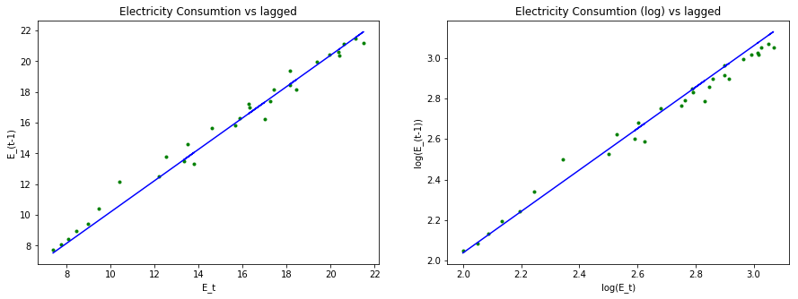

```python
mod_lag = smf.ols(formula='Finland ~ lag_Finland', data=energy_consumption).fit()
mod_lag_log = smf.ols(formula='np.log(Finland) ~ np.log(lag_Finland)', data=energy_consumption).fit()

fig = plt.figure(figsize=(15,5))
plt.subplot(121)
plt.plot(energy_consumption['Finland'], energy_consumption['lag_Finland'], 'g.')
plt.plot(energy_consumption['Finland'], energy_consumption['Finland']*mod_lag.params[1], 'b-')
plt.ylabel('E_(t-1)')
plt.xlabel('E_t')
plt.title('Electricity Consumtion vs lagged')

plt.subplot(122)
plt.plot(np.log(energy_consumption['Finland']), np.log(energy_consumption['lag_Finland']), 'g.')
plt.plot(np.log(energy_consumption['Finland']), np.log(energy_consumption['Finland'])*mod_lag.params[1], 'b-')
plt.ylabel('log(E_(t-1))')
plt.xlabel('log(E_t)')
plt.title('Electricity Consumtion (log) vs lagged')
```

### Model 4

The lag variable seems again to be the most relevant variable although a trend was added. Since the estimated signs are not correct this model will also be discarded.

## Model Selection Norway

The same models were also fitted to the data of Norway.

### Model 1

The fit seems not that good since the estimated signs of the coefficients are not a s expected and the degree of certainty is also comparably low. This model will therefore be discarded.

### Model 2

The fit seems to be a little bit better in terms of thedgree of certainty. But again, the estimated elasticities seem to be not as expected. Therefore, also this model will be dicarded.

### Model 3

Ths model looks much better. The coreected degree of certainty looks quite good. Also the estimated elaticities reflect our expactations correctly. Problably caused by the number of observations the coefficients cannot be significantly distinguished from zero.

### Model 4

```python
mod1n = smf.ols(formula='np.log(Norway) ~ np.log(GDP_real_Norway) + np.log(price_real_Norway)', data=energy_consumption).fit()
mod1n.summary()
```

OLS Regression Results

| Dep. Variable: | np.log(Norway) | R-squared: | 0.520 |
| --- | --- | --- | --- |
| Model: | OLS | Adj. R-squared: | 0.484 |
| Method: | Least Squares | F-statistic: | 14.61 |
| Date: | Thu, 16 Nov 2017 | Prob (F-statistic): | 5.02e-05 |
| Time: | 15:41:47 | Log-Likelihood: | 25.024 |
| No. Observations: | 30 | AIC: | -44.05 |
| Df Residuals: | 27 | BIC: | -39.85 |
| Df Model: | 2 |  |  |
| Covariance Type: | nonrobust |  |  |

|  | coef | std err | t | P>\|t\| | [0.025 | 0.975] |
| --- | --- | --- | --- | --- | --- | --- |
| Intercept | 2.1114 | 0.822 | 2.569 | 0.016 | 0.425 | 3.798 |
| np.log(GDP_real_Norway) | 0.2766 | 0.082 | 3.373 | 0.002 | 0.108 | 0.445 |
| np.log(price_real_Norway) | 0.0204 | 0.174 | 0.117 | 0.907 | -0.336 | 0.377 |

| Omnibus: | 4.275 | Durbin-Watson: | 0.137 |
| --- | --- | --- | --- |
| Prob(Omnibus): | 0.118 | Jarque-Bera (JB): | 3.080 |
| Skew: | -0.634 | Prob(JB): | 0.214 |
| Kurtosis: | 2.075 | Cond. No. | 238. |

```python
mod2n = smf.ols(formula='np.log(Norway) ~ np.log(GDP_real_Norway) + np.log(price_real_Norway) + index', data=energy_consumption).fit()
mod2n.summary()
```

OLS Regression Results

| Dep. Variable: | np.log(Norway) | R-squared: | 0.831 |
| --- | --- | --- | --- |
| Model: | OLS | Adj. R-squared: | 0.811 |
| Method: | Least Squares | F-statistic: | 42.62 |
| Date: | Thu, 16 Nov 2017 | Prob (F-statistic): | 3.52e-10 |
| Time: | 15:41:47 | Log-Likelihood: | 40.693 |
| No. Observations: | 30 | AIC: | -73.39 |
| Df Residuals: | 26 | BIC: | -67.78 |
| Df Model: | 3 |  |  |
| Covariance Type: | nonrobust |  |  |

|  | coef | std err | t | P>\|t\| | [0.025 | 0.975] |
| --- | --- | --- | --- | --- | --- | --- |
| Intercept | -54.6290 | 8.214 | -6.651 | 0.000 | -71.513 | -37.745 |
| np.log(GDP_real_Norway) | -0.3288 | 0.101 | -3.270 | 0.003 | -0.536 | -0.122 |
| np.log(price_real_Norway) | -0.0594 | 0.106 | -0.562 | 0.579 | -0.277 | 0.158 |
| index | 0.0299 | 0.004 | 6.921 | 0.000 | 0.021 | 0.039 |

| Omnibus: | 2.260 | Durbin-Watson: | 0.482 |
| --- | --- | --- | --- |
| Prob(Omnibus): | 0.323 | Jarque-Bera (JB): | 1.741 |
| Skew: | -0.586 | Prob(JB): | 0.419 |
| Kurtosis: | 2.857 | Cond. No. | 1.34e+06 |

```python
mod3n = smf.ols(formula='np.log(Norway) ~ np.log(GDP_real_Norway) + np.log(price_real_Norway) + np.log(lag_Norway)', data=energy_consumption).fit()
mod3n.summary()
```

OLS Regression Results

| Dep. Variable: | np.log(Norway) | R-squared: | 0.951 |
| --- | --- | --- | --- |
| Model: | OLS | Adj. R-squared: | 0.945 |
| Method: | Least Squares | F-statistic: | 167.9 |
| Date: | Thu, 16 Nov 2017 | Prob (F-statistic): | 3.91e-17 |
| Time: | 15:41:47 | Log-Likelihood: | 59.242 |
| No. Observations: | 30 | AIC: | -110.5 |
| Df Residuals: | 26 | BIC: | -104.9 |
| Df Model: | 3 |  |  |
| Covariance Type: | nonrobust |  |  |

|  | coef | std err | t | P>\|t\| | [0.025 | 0.975] |
| --- | --- | --- | --- | --- | --- | --- |
| Intercept | -0.3347 | 0.313 | -1.070 | 0.295 | -0.978 | 0.308 |
| np.log(GDP_real_Norway) | 0.0261 | 0.031 | 0.829 | 0.415 | -0.039 | 0.091 |
| np.log(price_real_Norway) | -0.0145 | 0.057 | -0.256 | 0.800 | -0.131 | 0.102 |
| np.log(lag_Norway) | 1.0439 | 0.069 | 15.116 | 0.000 | 0.902 | 1.186 |

| Omnibus: | 1.552 | Durbin-Watson: | 1.966 |
| --- | --- | --- | --- |
| Prob(Omnibus): | 0.460 | Jarque-Bera (JB): | 0.883 |
| Skew: | 0.418 | Prob(JB): | 0.643 |
| Kurtosis: | 3.095 | Cond. No. | 322. |

```python
mod4n = smf.ols(formula='np.log(Norway) ~ np.log(GDP_real_Norway) + np.log(price_real_Norway) + np.log(lag_Norway) + index', data=energy_consumption).fit()
mod4n.summary()
```

OLS Regression Results

| Dep. Variable: | np.log(Norway) | R-squared: | 0.959 |
| --- | --- | --- | --- |
| Model: | OLS | Adj. R-squared: | 0.953 |
| Method: | Least Squares | F-statistic: | 146.6 |
| Date: | Thu, 16 Nov 2017 | Prob (F-statistic): | 5.72e-17 |
| Time: | 15:41:47 | Log-Likelihood: | 61.982 |
| No. Observations: | 30 | AIC: | -114.0 |
| Df Residuals: | 25 | BIC: | -107.0 |
| Df Model: | 4 |  |  |
| Covariance Type: | nonrobust |  |  |

|  | coef | std err | t | P>\|t\| | [0.025 | 0.975] |
| --- | --- | --- | --- | --- | --- | --- |
| Intercept | -14.1052 | 6.159 | -2.290 | 0.031 | -26.790 | -1.421 |
| np.log(GDP_real_Norway) | -0.0847 | 0.057 | -1.473 | 0.153 | -0.203 | 0.034 |
| np.log(price_real_Norway) | -0.0288 | 0.053 | -0.542 | 0.593 | -0.138 | 0.081 |
| np.log(lag_Norway) | 0.8756 | 0.099 | 8.852 | 0.000 | 0.672 | 1.079 |
| index | 0.0075 | 0.003 | 2.238 | 0.034 | 0.001 | 0.014 |

| Omnibus: | 1.666 | Durbin-Watson: | 2.030 |
| --- | --- | --- | --- |
| Prob(Omnibus): | 0.435 | Jarque-Bera (JB): | 1.081 |
| Skew: | 0.121 | Prob(JB): | 0.582 |
| Kurtosis: | 2.102 | Cond. No. | 2.00e+06 |

## Differences between Finland and Norway

The differences between both countires are not that drastic. As so-called skandinavian countries this does not suprise. The model fit toe the data of finland seems to be a little better. This may be caused by the more continous development over time, while there seems to be a point of discontinuity in the data of Norway.

## Diagnostic Plots

To help with the model selection diagnostic plots for model 3 and 4 for Norway and model 1 and 3 for Finland are drwan blow.

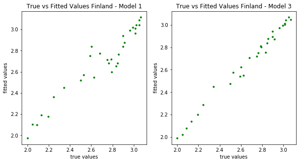

```python
fig = plt.figure(figsize=(10,5))
plt.subplot(121)
plt.plot(np.log(energy_consumption['Finland']), mod1f.predict(), 'g.')
plt.xlabel('true values')
plt.ylabel('fitted values')
plt.title('True vs Fitted Values Finland - Model 1')

plt.subplot(122)
plt.plot(np.log(energy_consumption['Finland'])[:-1], mod3f.predict(), 'g.')
plt.xlabel('true values')
plt.ylabel('fitted values')
plt.title('True vs Fitted Values Finland - Model 3')
```

Both model 1 and 3 are a good fit for the data. Model 3, however, seems to a better fit, the predicted and true values are almsot exactely on one line. Model 1 seems to have a little bit higher variance.

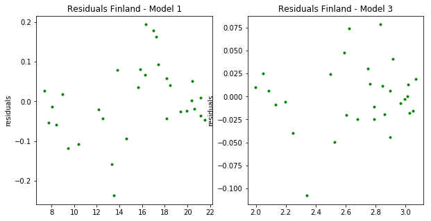

```python
fig = plt.figure(figsize=(10,5))
plt.subplot(121)
plt.plot((energy_consumption['Finland']), mod1f.resid, 'g.')
plt.ylabel('residuals')
plt.title('Residuals Finland - Model 1')

plt.subplot(122)
plt.plot(np.log(energy_consumption['Finland'])[:-1], mod3f.resid, 'g.')
plt.ylabel('residuals')
plt.title('Residuals Finland - Model 3')
```

The residuals of both models show no worrying behaviour, they are nicely distributed arround zero, with no obvious pattern

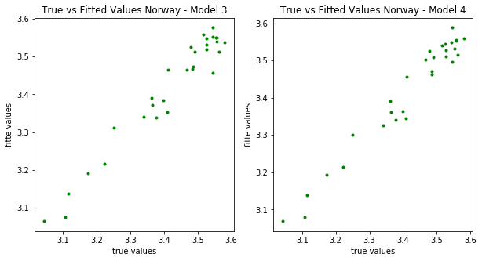

```python
fig = plt.figure(figsize=(10,5))
plt.subplot(121)
plt.plot(np.log(energy_consumption['Norway'])[:-1], mod3n.predict(), 'g.')
plt.xlabel('true values')
plt.ylabel('fitte values')
plt.title('True vs Fitted Values Norway - Model 3')

plt.subplot(122)
plt.plot(np.log(energy_consumption['Norway'])[:-1], mod4n.predict(), 'g.')
plt.xlabel('true values')
plt.ylabel('fitte values')
plt.title('True vs Fitted Values Norway - Model 4')
```

There seems to be no differnce between model 3 and 4 for Norway

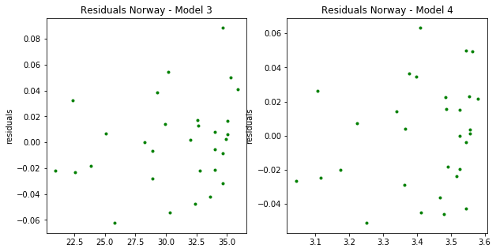

```python
fig = plt.figure(figsize=(10,5))
plt.subplot(121)
plt.plot((energy_consumption['Norway'])[:-1], mod3n.resid, 'g.')
plt.ylabel('residuals')
plt.title('Residuals Norway - Model 3')

plt.subplot(122)
plt.plot(np.log(energy_consumption['Norway'])[:-1], mod4n.resid, 'g.')
plt.ylabel('residuals')
plt.title('Residuals Norway - Model 4')
```

Also the residuals are almost the same. Quite nicely randomly distributed arround zero.

## Final Model Selection for Finland and Norway

Model 3 and 4 had the best results for Norway. The differences between the models seem to be negligible, therefor model 3 will be the selected model since it has fewer variables. To be sure one could run a F-test to determine wether or not model 3 and 4 differ significantly from each other. Model 1 and 3 had the best results for Finland. odel 3 seems to be a better fit ragarfing the degree of certainty and also regarding the diagostic plots. Depending on the purpose of the model and for what it may be used lateron the choice may be differnt. I also want to emphasize that a lot of other aspects and variables would improve the model. For example the influence of the climate change could be integrated into the model as well as the correlation between total efficiency and electricity. Also, an interesting aspect would be the individual consumer profile. If a rethinking of the cosumers regarding electricity consumption could be accieved such that more efficient and more energy-saving household appliances would be used, this could result in an important influence factor on electricity consumption.